# Analysis

## 4.4 CFA Muestra Pobreza

```r
w02pob <- data02 %>% filter(FL_6_DO_Tratamiento==1) %>% select(starts_with("meritv03_p"))
```

| Statistic | N | Mean | St. Dev. | Min | Pctl(25) | Pctl(75) | Max |
| --- | --- | --- | --- | --- | --- | --- | --- |
| meritv03_perc_effort | 586 | 3.387 | 1.260 | 1.000 | 2.000 | 4.000 | 5.000 |
| meritv03_perc_talent | 586 | 3.140 | 1.099 | 1.000 | 2.000 | 4.000 | 5.000 |
| meritv03_perc_wpart | 586 | 3.493 | 1.368 | 1.000 | 3.000 | 5.000 | 5.000 |
| meritv03_perc_netw | 586 | 3.534 | 1.274 | 1.000 | 3.000 | 4.000 | 5.000 |
| meritv03_pref_effort | 586 | 3.956 | 1.173 | 1.000 | 4.000 | 5.000 | 5.000 |
| meritv03_pref_talent | 586 | 3.304 | 1.135 | 1.000 | 3.000 | 4.000 | 5.000 |
| meritv03_pref_wpart | 586 | 2.654 | 1.142 | 1.000 | 2.000 | 3.000 | 5.000 |
| meritv03_pref_netw | 586 | 2.280 | 1.085 | 1.000 | 1.000 | 3.000 | 5.000 |

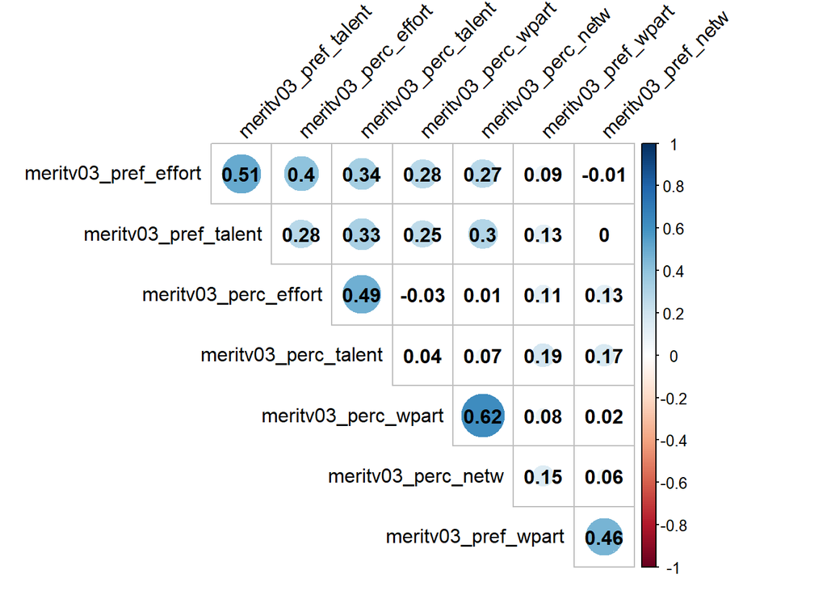

```r
corw02_2<-polychoric(w02pob)
corrplot(corw02_2$rho, type = "upper", order = "hclust", tl.col = "black", tl.srt = 45,addCoef.col = "black",diag = FALSE)
```

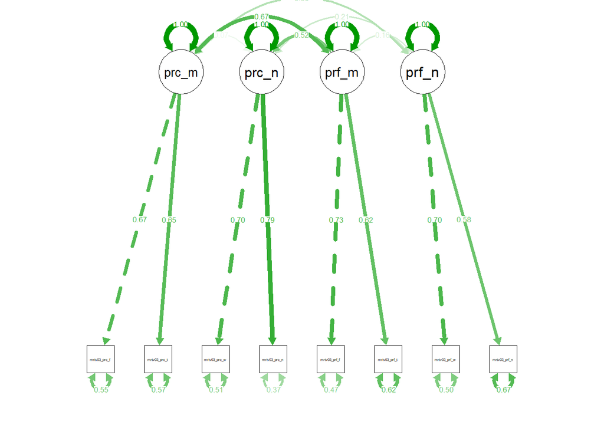

```r
model03 <- '
perc_merit=~meritv03_perc_effort+meritv03_perc_talent
perc_nmerit=~meritv03_perc_wpart+meritv03_perc_netw
pref_merit=~meritv03_pref_effort+meritv03_pref_talent
pref_nmerit=~meritv03_pref_wpart+meritv03_pref_netw'

fitw02b_c <- cfa(model = model03,data = w02pob,estimator="MLR") # Continuo/ estimador ML Robust

fitw02b_o <- cfa(model = model03,data = w02pob,ordered = c("meritv03_perc_effort","meritv03_perc_talent",
                                                     "meritv03_perc_wpart","meritv03_perc_netw",
                                                     "meritv03_pref_effort","meritv03_pref_talent",
                                                     "meritv03_pref_wpart","meritv03_pref_netw"))

#---------------------------------------------------#
#summary(fitw02b_c,standardized=TRUE, fit.measures=TRUE)
fitmeasures(fitw02b_c)[c("chisq.scaled","df","cfi","cfi.scaled","cfi.robust","rmsea","rmsea.scaled","rmsea.robust")]
semPlot::semPaths(object = fitw02b_c,what = "std",thresholds = FALSE, intercepts = FALSE, curve=2)
```

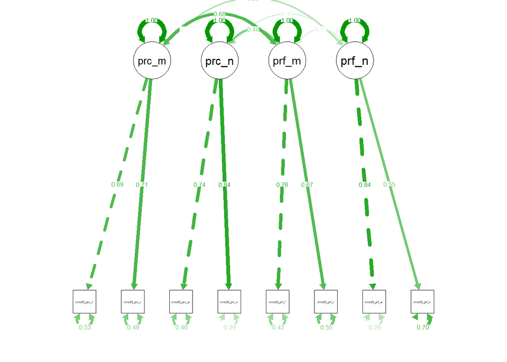

```
## chisq.scaled           df          cfi   cfi.scaled   cfi.robust
##  21.89512187  14.00000000   0.98686103   0.98728536   0.98891906
##        rmsea rmsea.scaled rmsea.robust
##   0.03601966   0.03102177   0.03291156
## chisq.scaled           df          cfi   cfi.scaled   cfi.robust
##  32.82736205  14.00000000   0.99739823   0.98732355           NA
##        rmsea rmsea.scaled rmsea.robust
##   0.02531526   0.04794604           NA
```

```r
#summary(fitw02b_o,standardized=TRUE, fit.measures=TRUE)
fitmeasures(fitw02b_o)[c("chisq.scaled","df","cfi","cfi.scaled","cfi.robust","rmsea","rmsea.scaled","rmsea.robust")]
semPlot::semPaths(object = fitw02b_o,what = "std",thresholds = FALSE, intercepts = FALSE, curve=2)
```

## 4.5 CFA Muestra Desigualdad

```r
w02des <- data02 %>% filter(FL_6_DO_Tratamiento_desigualdad==1) %>% select(starts_with("meritv03_p"))
```

| Statistic | N | Mean | St. Dev. | Min | Pctl(25) | Pctl(75) | Max |
| --- | --- | --- | --- | --- | --- | --- | --- |
| meritv03_perc_effort | 591 | 3.244 | 1.219 | 1.000 | 2.000 | 4.000 | 5.000 |
| meritv03_perc_talent | 591 | 3.069 | 1.099 | 1.000 | 2.000 | 4.000 | 5.000 |
| meritv03_perc_wpart | 591 | 3.611 | 1.311 | 1.000 | 3.000 | 5.000 | 5.000 |
| meritv03_perc_netw | 591 | 3.572 | 1.255 | 1.000 | 3.000 | 4.000 | 5.000 |
| meritv03_pref_effort | 591 | 3.939 | 1.130 | 1.000 | 3.000 | 5.000 | 5.000 |
| meritv03_pref_talent | 591 | 3.281 | 1.132 | 1.000 | 3.000 | 4.000 | 5.000 |
| meritv03_pref_wpart | 591 | 2.579 | 1.173 | 1.000 | 2.000 | 3.000 | 5.000 |
| meritv03_pref_netw | 591 | 2.272 | 1.034 | 1.000 | 1.000 | 3.000 | 5.000 |

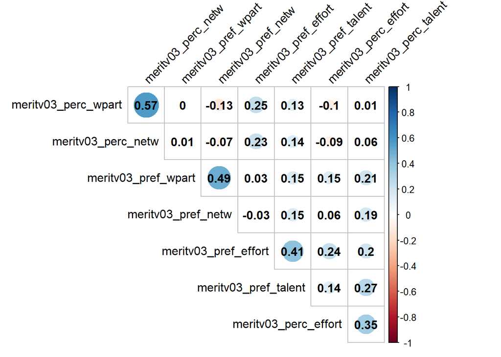

```r
corw02_3<-polychoric(w02des)
corrplot(corw02_3$rho, type = "upper", order = "hclust", tl.col = "black", tl.srt = 45,addCoef.col = "black",diag = FALSE)
```

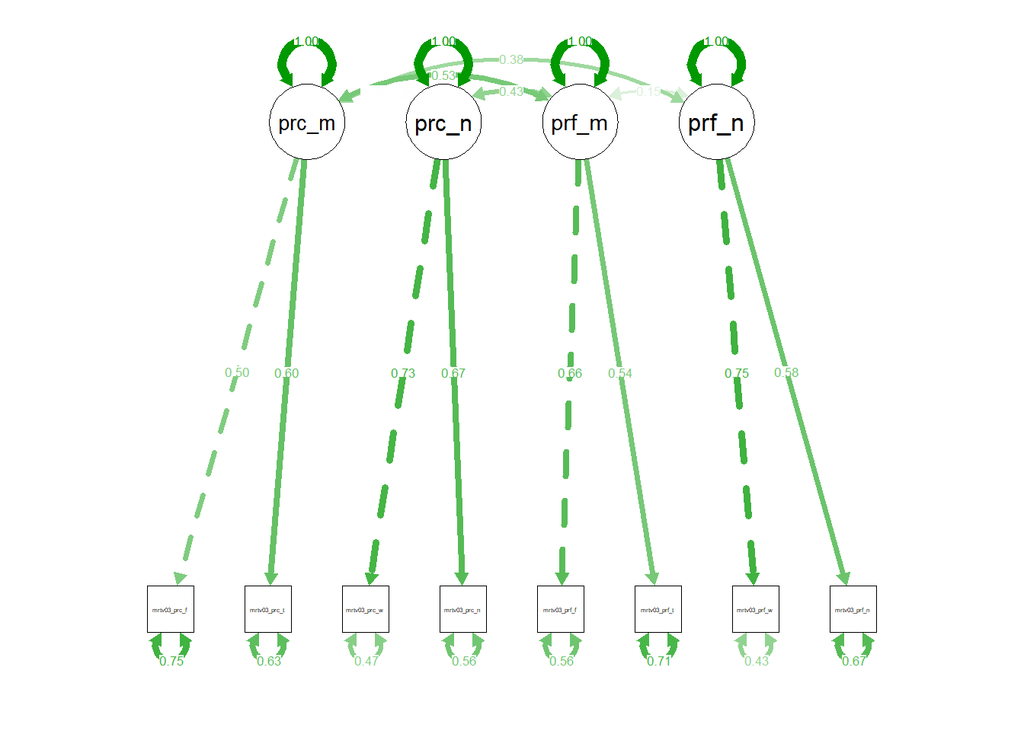

```r
model03 <- '
perc_merit=~meritv03_perc_effort+meritv03_perc_talent
perc_nmerit=~meritv03_perc_wpart+meritv03_perc_netw
pref_merit=~meritv03_pref_effort+meritv03_pref_talent
pref_nmerit=~meritv03_pref_wpart+meritv03_pref_netw'

fitw02c_c <- cfa(model = model03,data = w02des,estimator="MLR") # Continuo/ estimador ML Robust

fitw02c_o <- cfa(model = model03,data = w02des,ordered = c("meritv03_perc_effort","meritv03_perc_talent",
                                                           "meritv03_perc_wpart","meritv03_perc_netw",
                                                           "meritv03_pref_effort","meritv03_pref_talent",
                                                           "meritv03_pref_wpart","meritv03_pref_netw"))
#---------------------------------------------------#
#summary(fitw02c_c,standardized=TRUE, fit.measures=TRUE)
fitmeasures(fitw02c_c)[c("chisq.scaled","df","cfi","cfi.scaled","cfi.robust","rmsea","rmsea.scaled","rmsea.robust")]
semPlot::semPaths(object = fitw02c_c,what = "std",thresholds = FALSE, intercepts = FALSE)
```

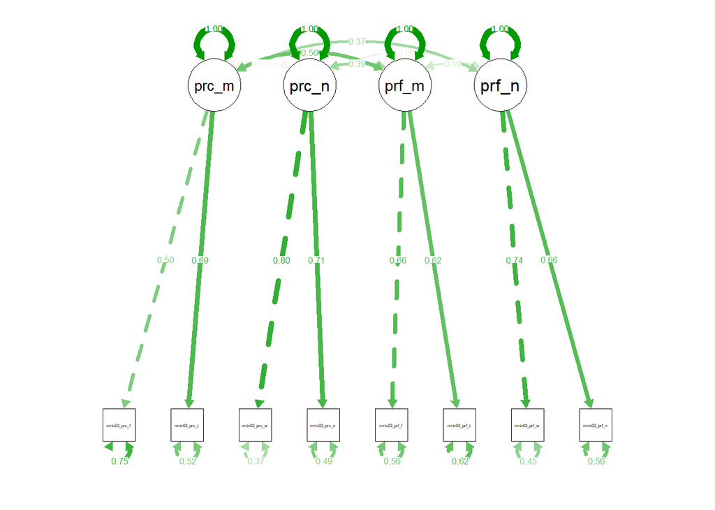

```
## chisq.scaled           df          cfi   cfi.scaled   cfi.robust
##  46.32268992  14.00000000   0.93940521   0.92687174   0.93936161
##        rmsea rmsea.scaled rmsea.robust
##   0.06371050   0.06250230   0.06334778
## chisq.scaled           df          cfi   cfi.scaled   cfi.robust
##  69.67269301  14.00000000   0.97297449   0.94366656           NA
##        rmsea rmsea.scaled rmsea.robust
##   0.06420276   0.08209772           NA
```

```r
#summary(fitw02b_o,standardized=TRUE, fit.measures=TRUE)
fitmeasures(fitw02c_o)[c("chisq.scaled","df","cfi","cfi.scaled","cfi.robust","rmsea","rmsea.scaled","rmsea.robust")]
semPlot::semPaths(object = fitw02c_o,what = "std",thresholds = FALSE, intercepts = FALSE)
```

# 5 Resumen ajuste ola 2

```r
sum_fitw02<- bind_rows(fitmeasures(fitw02_c)[ c("cfi","cfi.scaled","cfi.robust","rmsea","rmsea.scaled","rmsea.robust")],
                       fitmeasures(fitw02_o)[ c("cfi","cfi.scaled","cfi.robust","rmsea","rmsea.scaled","rmsea.robust")],
                       fitmeasures(fitw02a_c)[c("cfi","cfi.scaled","cfi.robust","rmsea","rmsea.scaled","rmsea.robust")],
                       fitmeasures(fitw02a_o)[c("cfi","cfi.scaled","cfi.robust","rmsea","rmsea.scaled","rmsea.robust")],
                       fitmeasures(fitw02b_c)[c("cfi","cfi.scaled","cfi.robust","rmsea","rmsea.scaled","rmsea.robust")],
                       fitmeasures(fitw02b_o)[c("cfi","cfi.scaled","cfi.robust","rmsea","rmsea.scaled","rmsea.robust")],
                       fitmeasures(fitw02c_c)[c("cfi","cfi.scaled","cfi.robust","rmsea","rmsea.scaled","rmsea.robust")],
                       fitmeasures(fitw02c_c)[c("cfi","cfi.scaled","cfi.robust","rmsea","rmsea.scaled","rmsea.robust")])

sum_fitw02$mod <- c("Modelo 1","Modelo 1","Modelo 2","Modelo 2","Modelo 3","Modelo 3","Modelo 4","Modelo 4")
sum_fitw02$est <- c("Continuo","Ordinal","Continuo","Ordinal","Continuo","Ordinal","Continuo","Ordinal")
sum_fitw02 <- select(sum_fitw02,mod,est,everything())

kable(sum_fitw02,digits = 3,format = "html",row.names = F,booktabs=T, caption = "Resumen ajuste ola 2") %>%
  kable_styling(full_width = F) %>%
  collapse_rows(columns = 1,valign = "middle") %>%
  footnote(number = c("Modelo 1: Muestra completa",
                      "Modelo 2: Muestra grupo Control",
                      "Modelo 3: Muestra grupo tratamiento pobreza",
                      "Modelo 4: Muestra grupo tratamiento desigualdad"))
```

Resumen ajuste ola 2

| mod | est | cfi | cfi.scaled | cfi.robust | rmsea | rmsea.scaled | rmsea.robust |
| --- | --- | --- | --- | --- | --- | --- | --- |
| Modelo 1 | Continuo | 0.967 | 0.965 | 0.968 | 0.051 | 0.046 | 0.050 |
|  | Ordinal | 0.988 | 0.975 |  | 0.047 | 0.060 |  |
| Modelo 2 | Continuo | 0.953 | 0.952 | 0.957 | 0.057 | 0.050 | 0.054 |
|  | Ordinal | 0.988 | 0.975 |  | 0.043 | 0.057 |  |
| Modelo 3 | Continuo | 0.987 | 0.987 | 0.989 | 0.036 | 0.031 | 0.033 |
|  | Ordinal | 0.997 | 0.987 |  | 0.025 | 0.048 |  |
| Modelo 4 | Continuo | 0.939 | 0.927 | 0.939 | 0.064 | 0.063 | 0.063 |
|  | Ordinal | 0.939 | 0.927 | 0.939 | 0.064 | 0.063 | 0.063 |

<sup>1</sup> Modelo 1: Muestra completa  
<sup>2</sup> Modelo 2: Muestra grupo Control  
<sup>3</sup> Modelo 3: Muestra grupo tratamiento pobreza  
<sup>4</sup> Modelo 4: Muestra grupo tratamiento desigualdad

# 6 Wave 03

```r
data03 <- sjlabelled::read_spss(path = "input/data/original/Estudio_3_ola3.sav",verbose = FALSE)
dat01 <- data03 %>% select(starts_with("meritv03_p"))
```

```r
sjt.fa(data = dat01,show.comm = TRUE)
```

```
## Parallel analysis suggests that the number of factors =  3  and the number of components =  NA
```

Factor Analysis

|  | Factor 1 | Factor 2 | Factor 3 | Communality |
| --- | --- | --- | --- | --- |
| Pensando en la sociedad chilena, ¿En qué medida se encuentra usted de acuerdo o en desacuerdo con cada una de las siguientes afirmaciones? - Quienes más se esfuerzan logran obtener mayores recompen… | 0.66 | -0.28 | 0.09 | 0.45 |
| Pensando en la sociedad chilena, ¿En qué medida se encuentra usted de acuerdo o en desacuerdo con cada una de las siguientes afirmaciones? - Quienes poseen más talento logran obtener mayores recomp… | 0.58 | -0.09 | 0.13 | 0.36 |
| Pensando en la sociedad chilena, ¿En qué medida se encuentra usted de acuerdo o en desacuerdo con cada una de las siguientes afirmaciones? - Quienes tienen padres ricos logran salir adelante. | -0.05 | 0.73 | 0.08 | 0.52 |
| Pensando en la sociedad chilena, ¿En qué medida se encuentra usted de acuerdo o en desacuerdo con cada una de las siguientes afirmaciones? - Quienes tienen buenos contactos logran salir adelante. | -0.02 | 0.71 | 0.09 | 0.50 |
| Pensando en la sociedad chilena, ¿En qué medida se encuentra usted de acuerdo o en desacuerdo con cada una de las siguientes afirmaciones? - Quienes más se esfuerzan deberían obtener mayores recom… | 0.55 | 0.19 | -0.15 | 0.39 |
| Pensando en la sociedad chilena, ¿En qué medida se encuentra usted de acuerdo o en desacuerdo con cada una de las siguientes afirmaciones? - Quienes poseen más talento deberían obtener mayores rec… | 0.43 | 0.23 | -0.07 | 0.28 |
| Pensando en la sociedad chilena, ¿En qué medida se encuentra usted de acuerdo o en desacuerdo con cada una de las siguientes afirmaciones? - Está bien que quienes tienen padres ricos salgan adelant… | 0.03 | 0.13 | 0.75 | 0.58 |
| Pensando en la sociedad chilena, ¿En qué medida se encuentra usted de acuerdo o en desacuerdo con cada una de las siguientes afirmaciones? - Está bien que quienes tienen buenos contactos salgan ade… | 0.02 | 0.06 | 0.69 | 0.49 |
| Total Communalities |  |  |  | 3.58 |
| Cronbach’s α | 0.62 | 0.68 | 0.69 |  |

```r
model03 <- '
perc_merit=~meritv03_perc_effort+meritv03_perc_talent
perc_nmerit=~meritv03_perc_wpart+meritv03_perc_netw
pref_merit=~meritv03_pref_effort+meritv03_pref_talent
pref_nmerit=~meritv03_pref_wpart+meritv03_pref_netw'

fitw03c_c <- cfa(model = model03,data = dat01,estimator="MLR") # Continuo/ estimador ML Robust

fitw03c_o <- cfa(model = model03,data = dat01,ordered = c("meritv03_perc_effort","meritv03_perc_talent",
                                                          "meritv03_perc_wpart","meritv03_perc_netw",
                                                          "meritv03_pref_effort","meritv03_pref_talent",
                                                          "meritv03_pref_wpart","meritv03_pref_netw"))
#---------------------------------------------------#
#summary(fitw03c_c,standardized=TRUE, fit.measures=TRUE)
fitmeasures(fitw03c_c)[c("chisq.scaled","df","cfi","cfi.scaled","cfi.robust","rmsea","rmsea.scaled","rmsea.robust")]
```

```
## chisq.scaled           df          cfi   cfi.scaled   cfi.robust
##  62.42098851  14.00000000   0.97001271   0.96743840   0.97104967
##        rmsea rmsea.scaled rmsea.robust
##   0.05354429   0.04868836   0.05249427
```

```r
#summary(fitw03c_o,standardized=TRUE, fit.measures=TRUE)
fitmeasures(fitw03c_o)[c("chisq.scaled","df","cfi","cfi.scaled","cfi.robust","rmsea","rmsea.scaled","rmsea.robust")]
```

```
## chisq.scaled           df          cfi   cfi.scaled   cfi.robust
## 106.11132208  14.00000000   0.98842335   0.97425449           NA
##        rmsea rmsea.scaled rmsea.robust
##   0.05216642   0.06717594           NA
```

**summary** > * Ajuste usando estimador MLR es bueno (CFI = 0.971, RMSEA = 0.052). El chi2 (robusto) es 62.421  
> * Ajuste usando estimador DWLS es bueno (CFI = 0.974, RMSEA = 0.067). El chi2 (robusto) es 106.111

# 7 Resumen ajuste ola 3

```r
sum_fitw03<- bind_rows(fitmeasures(fitw03c_c)[ c("cfi","cfi.scaled","cfi.robust","rmsea","rmsea.scaled","rmsea.robust")],
                       fitmeasures(fitw03c_o)[ c("cfi","cfi.scaled","cfi.robust","rmsea","rmsea.scaled","rmsea.robust")])

sum_fitw03$mod <- c("Modelo 1","Modelo 1")
sum_fitw03$est <- c("Continuo","Ordinal")
sum_fitw03 <- select(sum_fitw03,mod,est,everything())

kable(sum_fitw03,digits = 3,format = "html",row.names = F,booktabs=T,caption = "Resumen ajuste ola 3") %>%
  kable_styling(full_width = F) %>%
  collapse_rows(columns = 1,valign = "middle") %>%
  footnote(number = c("Modelo 1: Muestra completa"))
```

Resumen ajuste ola 3

| mod | est | cfi | cfi.scaled | cfi.robust | rmsea | rmsea.scaled | rmsea.robust |
| --- | --- | --- | --- | --- | --- | --- | --- |
| Modelo 1 | Continuo | 0.970 | 0.967 | 0.971 | 0.054 | 0.049 | 0.052 |
|  | Ordinal | 0.988 | 0.974 |  | 0.052 | 0.067 |  |

<sup>1</sup> Modelo 1: Muestra completa

# 8 Análisis longitudinal

```r
library(sjPlot)
library(dplyr)
library(lavaan)
library(stargazer)
library(corrplot)
library(psych)
library(knitr)
library(kableExtra)
load(file = "input/data/proc/datawide_123.RData")
```

```r
g01<- wide02 %>% filter(grupo==1) %>% select(starts_with("perc_"),starts_with("pref_")) # Fixed by perception/preference
g02<- wide02 %>% filter(grupo==2) %>% select(starts_with("perc_"),starts_with("pref_")) # Fixed by topic (i.e: effort)
g03<- wide02 %>% filter(grupo==3) %>% select(starts_with("perc_"),starts_with("pref_")) # Randomized
```

### 8.1.1 Grupo Versión 01

```r
stargazer(g01,type = "html", median = T,digits = 2)
```

| Statistic | N | Mean | St. Dev. | Min | Pctl(25) | Median | Pctl(75) | Max |
| --- | --- | --- | --- | --- | --- | --- | --- | --- |
| perc_effort_w1 | 486 | 3.22 | 1.35 | 1 | 2 | 3 | 4 | 5 |
| perc_talent_w1 | 486 | 3.02 | 1.11 | 1 | 2 | 3 | 4 | 5 |
| perc_wpart_w1 | 486 | 3.61 | 1.36 | 1 | 3 | 4 | 5 | 5 |
| perc_netw_w1 | 486 | 3.76 | 1.23 | 1 | 3 | 4 | 5 | 5 |
| perc_effort_w2 | 486 | 3.33 | 1.23 | 1 | 2 | 3.5 | 4 | 5 |
| perc_talent_w2 | 486 | 3.13 | 1.09 | 1 | 2 | 3 | 4 | 5 |
| perc_wpart_w2 | 486 | 3.59 | 1.30 | 1 | 3 | 4 | 5 | 5 |
| perc_netw_w2 | 486 | 3.56 | 1.26 | 1 | 3 | 4 | 4 | 5 |
| perc_effort_w3 | 486 | 3.47 | 1.16 | 1 | 3 | 4 | 4 | 5 |
| perc_talent_w3 | 486 | 3.18 | 1.01 | 1 | 3 | 3 | 4 | 5 |
| perc_wpart_w3 | 486 | 3.38 | 1.30 | 1 | 3 | 4 | 4 | 5 |
| perc_netw_w3 | 486 | 3.52 | 1.20 | 1 | 3 | 4 | 4 | 5 |
| pref_effort_w1 | 486 | 3.91 | 1.24 | 1 | 3 | 4 | 5 | 5 |
| pref_talent_w1 | 486 | 3.33 | 1.15 | 1 | 3 | 3 | 4 | 5 |
| pref_wpart_w1 | 486 | 2.54 | 1.12 | 1 | 2 | 3 | 3 | 5 |
| pref_netw_w1 | 486 | 2.30 | 1.06 | 1 | 1 | 2 | 3 | 5 |
| pref_effort_w2 | 486 | 3.92 | 1.13 | 1 | 3 | 4 | 5 | 5 |
| pref_talent_w2 | 486 | 3.30 | 1.10 | 1 | 3 | 3 | 4 | 5 |
| pref_wpart_w2 | 486 | 2.60 | 1.14 | 1 | 2 | 3 | 3 | 5 |
| pref_netw_w2 | 486 | 2.29 | 1.09 | 1 | 1 | 2 | 3 | 5 |
| pref_effort_w3 | 486 | 4.03 | 1.11 | 1 | 4 | 4 | 5 | 5 |
| pref_talent_w3 | 486 | 3.49 | 1.01 | 1 | 3 | 4 | 4 | 5 |
| pref_wpart_w3 | 486 | 2.51 | 1.16 | 1 | 2 | 3 | 3 | 5 |
| pref_netw_w3 | 486 | 2.35 | 1.08 | 1 | 2 | 2 | 3 | 5 |

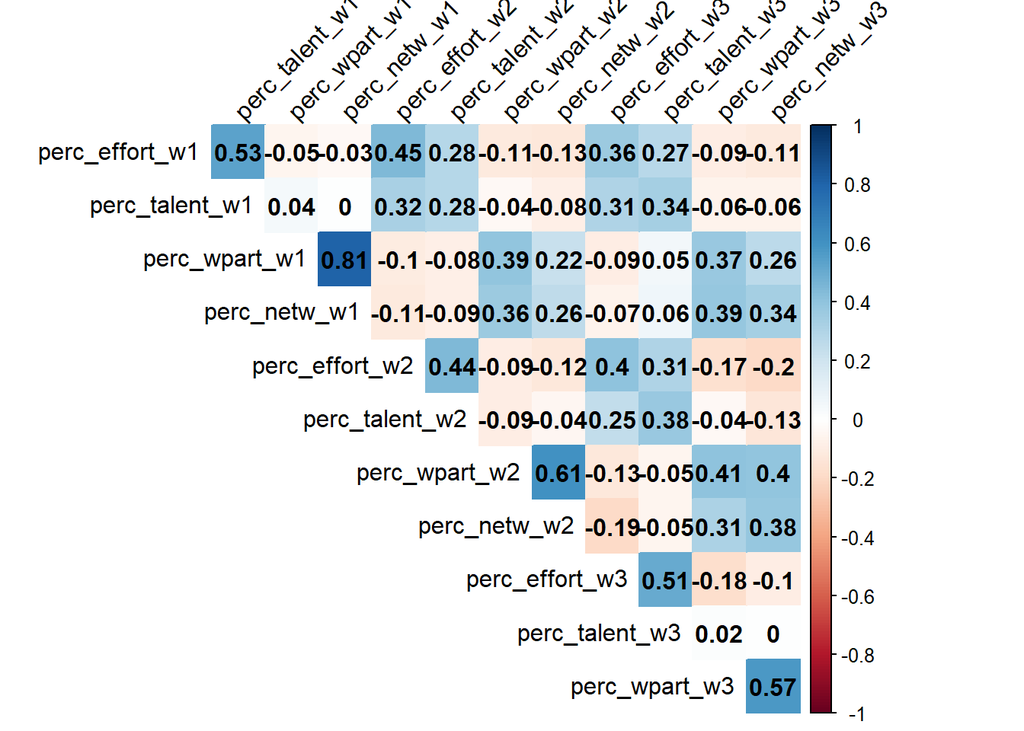

Percepción

```r
corwide01a<- polychoric(x = select(g01 ,starts_with(match = "perc_")),na.rm = T)
corrplot(corwide01a$rho, method = "color" ,type = "upper", tl.col = "black", tl.srt = 45,addCoef.col = "black",diag = FALSE)
```

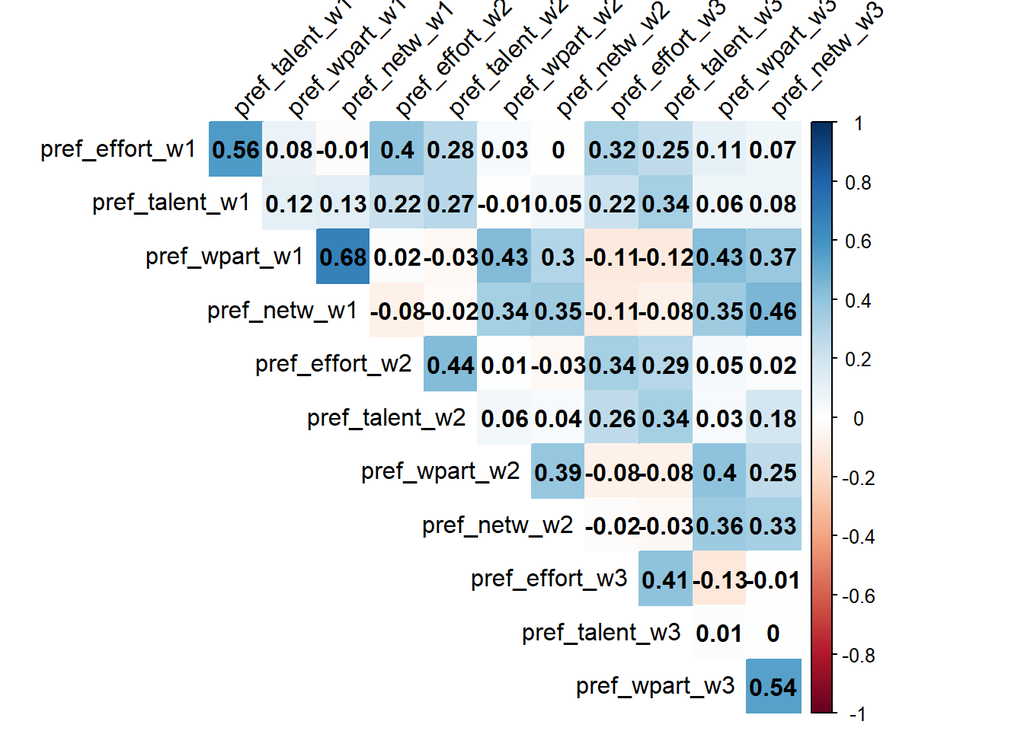

Preferencia

```r
corwide01b<- polychoric(x = select(g01 ,starts_with(match = "pref_")),na.rm = T)
corrplot(corwide01b$rho, method = "color" ,type = "upper", tl.col = "black", tl.srt = 45,addCoef.col = "black",diag = FALSE)
```

### 8.1.2 Grupo Versión 02

```r
stargazer(g02,type = "html", median = T,digits = 2)
```

| Statistic | N | Mean | St. Dev. | Min | Pctl(25) | Median | Pctl(75) | Max |
| --- | --- | --- | --- | --- | --- | --- | --- | --- |
| perc_effort_w1 | 471 | 3.10 | 1.42 | 1 | 2 | 3 | 4 | 5 |
| perc_talent_w1 | 471 | 3.09 | 1.13 | 1 | 2 | 3 | 4 | 5 |
| perc_wpart_w1 | 471 | 3.65 | 1.36 | 1 | 3 | 4 | 5 | 5 |
| perc_netw_w1 | 471 | 3.68 | 1.22 | 1 | 3 | 4 | 5 | 5 |
| perc_effort_w2 | 471 | 3.35 | 1.25 | 1 | 2 | 4 | 4 | 5 |
| perc_talent_w2 | 471 | 3.14 | 1.10 | 1 | 2 | 3 | 4 | 5 |
| perc_wpart_w2 | 471 | 3.59 | 1.26 | 1 | 3 | 4 | 5 | 5 |
| perc_netw_w2 | 471 | 3.61 | 1.20 | 1 | 3 | 4 | 4 | 5 |
| perc_effort_w3 | 471 | 3.54 | 1.22 | 1 | 3 | 4 | 5 | 5 |
| perc_talent_w3 | 471 | 3.21 | 1.06 | 1 | 2.5 | 3 | 4 | 5 |
| perc_wpart_w3 | 471 | 3.41 | 1.27 | 1 | 3 | 4 | 4 | 5 |
| perc_netw_w3 | 471 | 3.43 | 1.28 | 1 | 3 | 4 | 4 | 5 |
| pref_effort_w1 | 471 | 3.75 | 1.34 | 1 | 3 | 4 | 5 | 5 |
| pref_talent_w1 | 471 | 3.18 | 1.15 | 1 | 2 | 3 | 4 | 5 |
| pref_wpart_w1 | 471 | 2.77 | 1.20 | 1 | 2 | 3 | 4 | 5 |
| pref_netw_w1 | 471 | 2.39 | 1.09 | 1 | 2 | 2 | 3 | 5 |
| pref_effort_w2 | 471 | 4.00 | 1.14 | 1 | 4 | 4 | 5 | 5 |
| pref_talent_w2 | 471 | 3.27 | 1.15 | 1 | 2.5 | 3 | 4 | 5 |
| pref_wpart_w2 | 471 | 2.59 | 1.15 | 1 | 2 | 3 | 3 | 5 |
| pref_netw_w2 | 471 | 2.30 | 1.03 | 1 | 2 | 2 | 3 | 5 |
| pref_effort_w3 | 471 | 4.11 | 1.08 | 1 | 4 | 4 | 5 | 5 |
| pref_talent_w3 | 471 | 3.45 | 1.12 | 1 | 3 | 4 | 4 | 5 |
| pref_wpart_w3 | 471 | 2.53 | 1.14 | 1 | 2 | 3 | 3 | 5 |
| pref_netw_w3 | 471 | 2.28 | 1.05 | 1 | 1 | 2 | 3 | 5 |

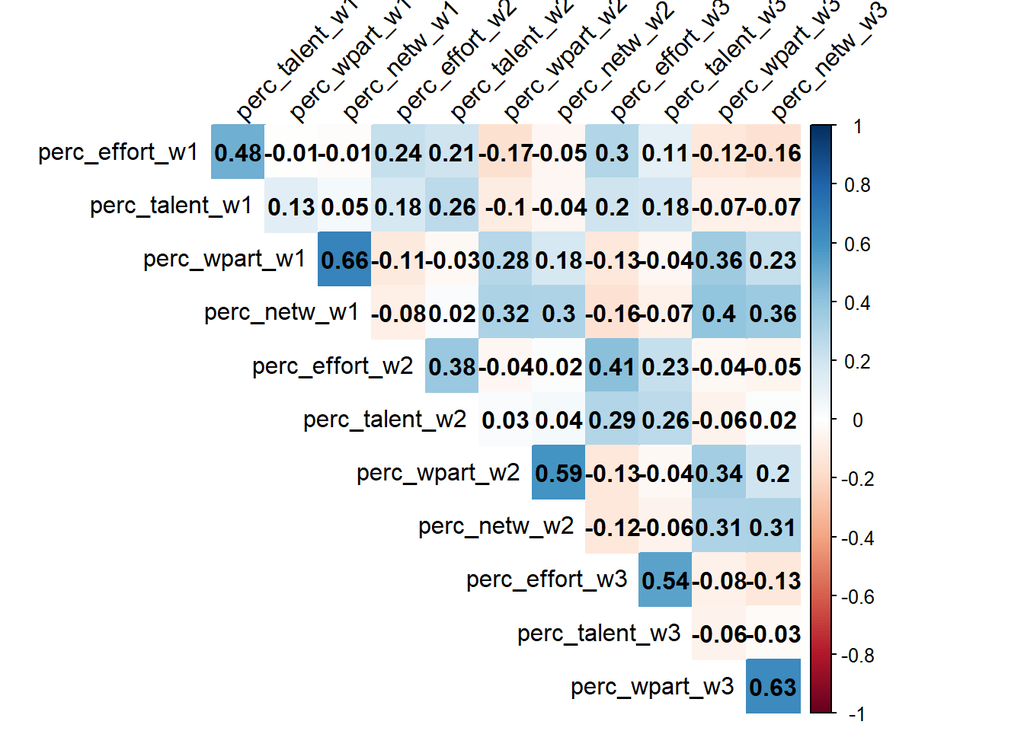

Percepción

```r
corwide02a<- polychoric(x = select(g02 ,starts_with(match = "perc_")),na.rm = T)
corrplot(corwide02a$rho, method = "color" ,type = "upper", tl.col = "black", tl.srt = 45,addCoef.col = "black",diag = FALSE)
```

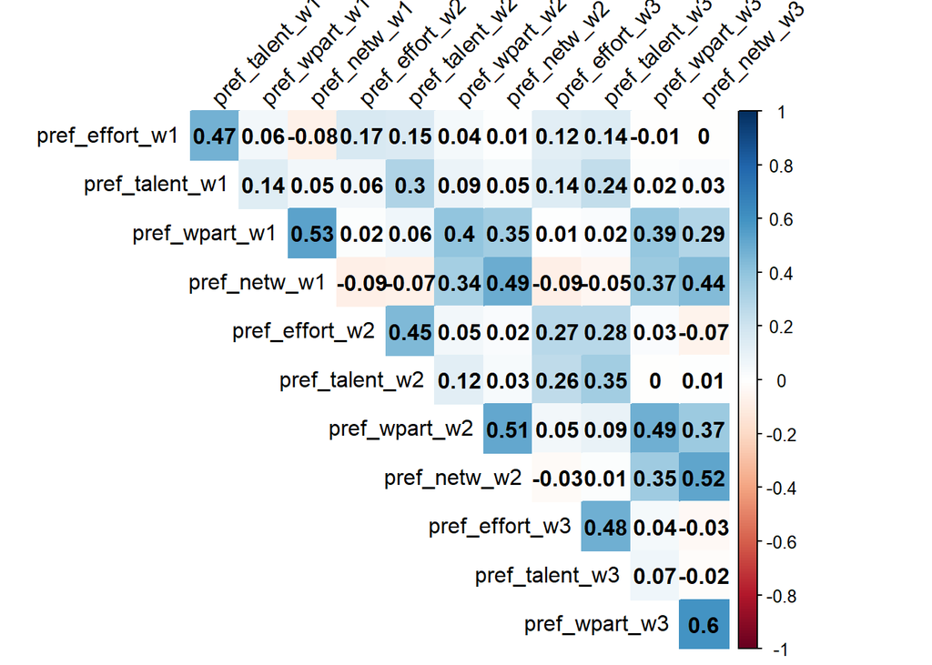

Preferencia

```r
corwide02b<- polychoric(x = select(g02 ,starts_with(match = "pref_")),na.rm = T)
corrplot(corwide02b$rho, method = "color" ,type = "upper", tl.col = "black", tl.srt = 45,addCoef.col = "black",diag = FALSE)
```

### 8.1.3 Grupo Versión 03

```r
stargazer(g03,type = "html", median = T,digits = 2)
```

| Statistic | N | Mean | St. Dev. | Min | Pctl(25) | Median | Pctl(75) | Max |
| --- | --- | --- | --- | --- | --- | --- | --- | --- |
| perc_effort_w1 | 491 | 3.41 | 1.34 | 1 | 2 | 4 | 5 | 5 |
| perc_talent_w1 | 491 | 3.12 | 1.24 | 1 | 2 | 3 | 4 | 5 |
| perc_wpart_w1 | 491 | 3.76 | 1.34 | 1 | 3 | 4 | 5 | 5 |
| perc_netw_w1 | 491 | 3.92 | 1.22 | 1 | 3 | 4 | 5 | 5 |
| perc_effort_w2 | 491 | 3.32 | 1.24 | 1 | 2 | 4 | 4 | 5 |
| perc_talent_w2 | 491 | 3.13 | 1.09 | 1 | 2 | 3 | 4 | 5 |
| perc_wpart_w2 | 491 | 3.44 | 1.41 | 1 | 2 | 4 | 5 | 5 |
| perc_netw_w2 | 491 | 3.50 | 1.28 | 1 | 3 | 4 | 4 | 5 |
| perc_effort_w3 | 491 | 3.49 | 1.23 | 1 | 3 | 4 | 4.5 | 5 |
| perc_talent_w3 | 491 | 3.21 | 1.01 | 1 | 3 | 3 | 4 | 5 |
| perc_wpart_w3 | 491 | 3.41 | 1.31 | 1 | 3 | 4 | 4 | 5 |
| perc_netw_w3 | 491 | 3.40 | 1.25 | 1 | 3 | 4 | 4 | 5 |
| pref_effort_w1 | 491 | 4.14 | 1.11 | 1 | 4 | 4 | 5 | 5 |
| pref_talent_w1 | 491 | 3.41 | 1.24 | 1 | 3 | 4 | 4 | 5 |
| pref_wpart_w1 | 491 | 2.79 | 1.19 | 1 | 2 | 3 | 4 | 5 |
| pref_netw_w1 | 491 | 2.48 | 1.15 | 1 | 2 | 2 | 3 | 5 |
| pref_effort_w2 | 491 | 3.88 | 1.20 | 1 | 3 | 4 | 5 | 5 |
| pref_talent_w2 | 491 | 3.30 | 1.10 | 1 | 3 | 3 | 4 | 5 |
| pref_wpart_w2 | 491 | 2.58 | 1.16 | 1 | 2 | 3 | 3 | 5 |
| pref_netw_w2 | 491 | 2.32 | 1.04 | 1 | 2 | 2 | 3 | 5 |
| pref_effort_w3 | 491 | 4.05 | 1.08 | 1 | 4 | 4 | 5 | 5 |
| pref_talent_w3 | 491 | 3.45 | 1.09 | 1 | 3 | 3 | 4 | 5 |
| pref_wpart_w3 | 491 | 2.53 | 1.14 | 1 | 2 | 3 | 3 | 5 |
| pref_netw_w3 | 491 | 2.34 | 1.07 | 1 | 1 | 2 | 3 | 5 |

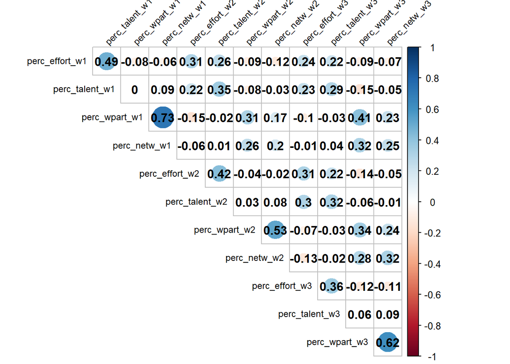

Percepción

```r
corwide03a<- polychoric(x = select(g03 ,starts_with(match = "perc_")),na.rm = T)
corrplot(corwide03a$rho, type = "upper", tl.col = "black", tl.srt = 45,addCoef.col = "black",diag = FALSE,tl.cex = 0.75)
```

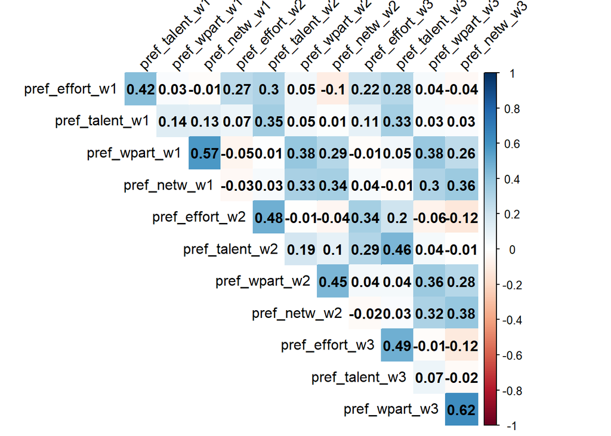

Preferencia

```r
corwide03b<- polychoric(x = select(g03 ,starts_with(match = "pref_")),na.rm = T)
corrplot(corwide03b$rho, method = "color" ,type = "upper", tl.col = "black", tl.srt = 45,addCoef.col = "black",diag = FALSE)
```

### 8.1.4 Muestra completa

```r
stargazer(select(wide02 ,starts_with(match = "perc_"), starts_with("pref_")),type = "html", median = T,digits = 2)
```

| Statistic | N | Mean | St. Dev. | Min | Pctl(25) | Median | Pctl(75) | Max |
| --- | --- | --- | --- | --- | --- | --- | --- | --- |
| perc_effort_w1 | 1,448 | 3.24 | 1.38 | 1 | 2 | 3 | 4 | 5 |
| perc_talent_w1 | 1,448 | 3.08 | 1.16 | 1 | 2 | 3 | 4 | 5 |
| perc_wpart_w1 | 1,448 | 3.67 | 1.35 | 1 | 3 | 4 | 5 | 5 |
| perc_netw_w1 | 1,448 | 3.79 | 1.23 | 1 | 3 | 4 | 5 | 5 |
| perc_effort_w2 | 1,448 | 3.33 | 1.24 | 1 | 2 | 4 | 4 | 5 |
| perc_talent_w2 | 1,448 | 3.13 | 1.09 | 1 | 2 | 3 | 4 | 5 |
| perc_wpart_w2 | 1,448 | 3.54 | 1.33 | 1 | 3 | 4 | 5 | 5 |
| perc_netw_w2 | 1,448 | 3.55 | 1.25 | 1 | 3 | 4 | 4 | 5 |
| perc_effort_w3 | 1,448 | 3.50 | 1.20 | 1 | 3 | 4 | 4 | 5 |
| perc_talent_w3 | 1,448 | 3.20 | 1.03 | 1 | 3 | 3 | 4 | 5 |
| perc_wpart_w3 | 1,448 | 3.40 | 1.29 | 1 | 3 | 4 | 4 | 5 |
| perc_netw_w3 | 1,448 | 3.45 | 1.24 | 1 | 3 | 4 | 4 | 5 |
| pref_effort_w1 | 1,448 | 3.93 | 1.24 | 1 | 3 | 4 | 5 | 5 |
| pref_talent_w1 | 1,448 | 3.31 | 1.18 | 1 | 3 | 3 | 4 | 5 |
| pref_wpart_w1 | 1,448 | 2.70 | 1.18 | 1 | 2 | 3 | 4 | 5 |
| pref_netw_w1 | 1,448 | 2.39 | 1.10 | 1 | 1.8 | 2 | 3 | 5 |
| pref_effort_w2 | 1,448 | 3.93 | 1.16 | 1 | 3 | 4 | 5 | 5 |
| pref_talent_w2 | 1,448 | 3.29 | 1.12 | 1 | 3 | 3 | 4 | 5 |
| pref_wpart_w2 | 1,448 | 2.59 | 1.15 | 1 | 2 | 3 | 3 | 5 |
| pref_netw_w2 | 1,448 | 2.30 | 1.05 | 1 | 1 | 2 | 3 | 5 |
| pref_effort_w3 | 1,448 | 4.06 | 1.09 | 1 | 4 | 4 | 5 | 5 |
| pref_talent_w3 | 1,448 | 3.46 | 1.07 | 1 | 3 | 4 | 4 | 5 |
| pref_wpart_w3 | 1,448 | 2.53 | 1.15 | 1 | 2 | 3 | 3 | 5 |
| pref_netw_w3 | 1,448 | 2.32 | 1.07 | 1 | 1 | 2 | 3 | 5 |

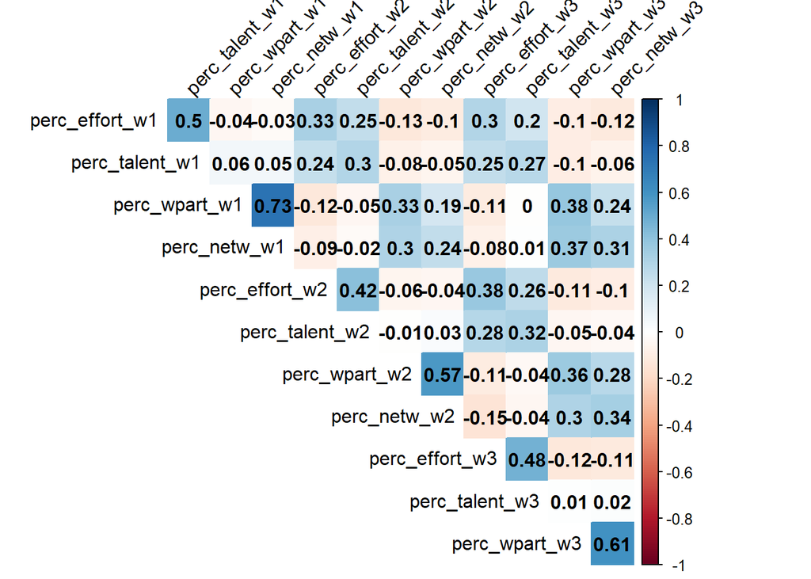

Percepción

```r
corwideA<- polychoric(x = select(wide02 ,starts_with(match = "perc_")),na.rm = T)
corrplot(corwideA$rho, method = "color" ,type = "upper", tl.col = "black", tl.srt = 45,addCoef.col = "black",diag = FALSE)
```

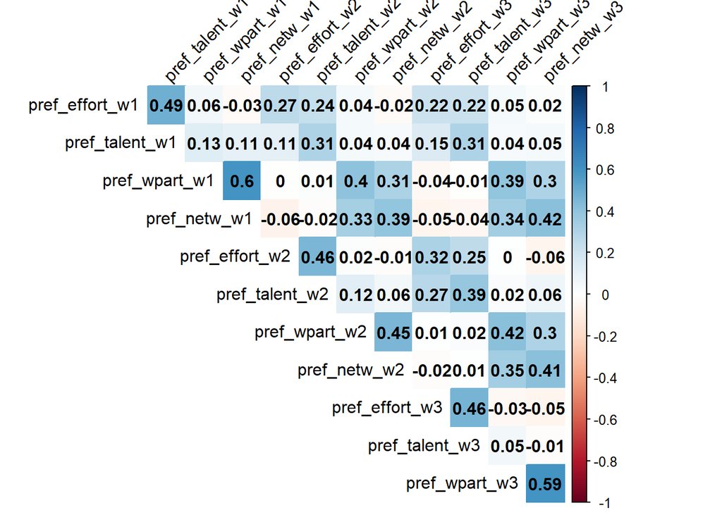

Preferencia

```r
corwideB<- polychoric(x = select(wide02 ,starts_with(match = "pref_")),na.rm = T)
corrplot(corwideB$rho, method = "color" ,type = "upper", tl.col = "black", tl.srt = 45,addCoef.col = "black",diag = FALSE)
```

## 8.2 CFA wave01, wave02 y wave03

```r
model_long <- '
# wave 01
perc_merit1 =~perc_effort_w1+perc_talent_w1
perc_nmerit1=~perc_wpart_w1 +perc_netw_w1
pref_merit1 =~pref_effort_w1+pref_talent_w1
pref_nmerit1=~pref_wpart_w1 +pref_netw_w1
# wave 02
perc_merit2 =~perc_effort_w2+perc_talent_w2
perc_nmerit2=~perc_wpart_w2 +perc_netw_w2
pref_merit2 =~pref_effort_w2+pref_talent_w2
pref_nmerit2=~pref_wpart_w2 +pref_netw_w2
# wave 03
perc_merit3 =~perc_effort_w3+perc_talent_w3
perc_nmerit3=~perc_wpart_w3 +perc_netw_w3
pref_merit3 =~pref_effort_w3+pref_talent_w3
pref_nmerit3=~pref_wpart_w3 +pref_netw_w3'


fitlong_c <- cfa(model = model_long,data = wide02,estimator="MLR") # Continuo/ estimador ML Robust

indicadores <-c("perc_effort_w1","perc_talent_w1","perc_wpart_w1","perc_netw_w1",
                "pref_effort_w1","pref_talent_w1","pref_wpart_w1","pref_netw_w1",
                "perc_effort_w2","perc_talent_w2","perc_wpart_w2","perc_netw_w2",
                "pref_effort_w2","pref_talent_w2","pref_wpart_w2","pref_netw_w2")

fitlong_o <- cfa(model = model_long,data = wide02,ordered = indicadores)

#---------------------------------------------------#
#summary(fitlong_c,standardized=TRUE, fit.measures=TRUE)
fitmeasures(fitlong_c)[c("chisq.scaled","df","cfi","cfi.scaled","cfi.robust","rmsea","rmsea.scaled","rmsea.robust")]
```

```
## chisq.scaled           df          cfi   cfi.scaled   cfi.robust
## 665.88017314 186.00000000   0.93012912   0.92988159   0.93302455
##        rmsea rmsea.scaled rmsea.robust
##   0.04637638   0.04221100   0.04525147
```

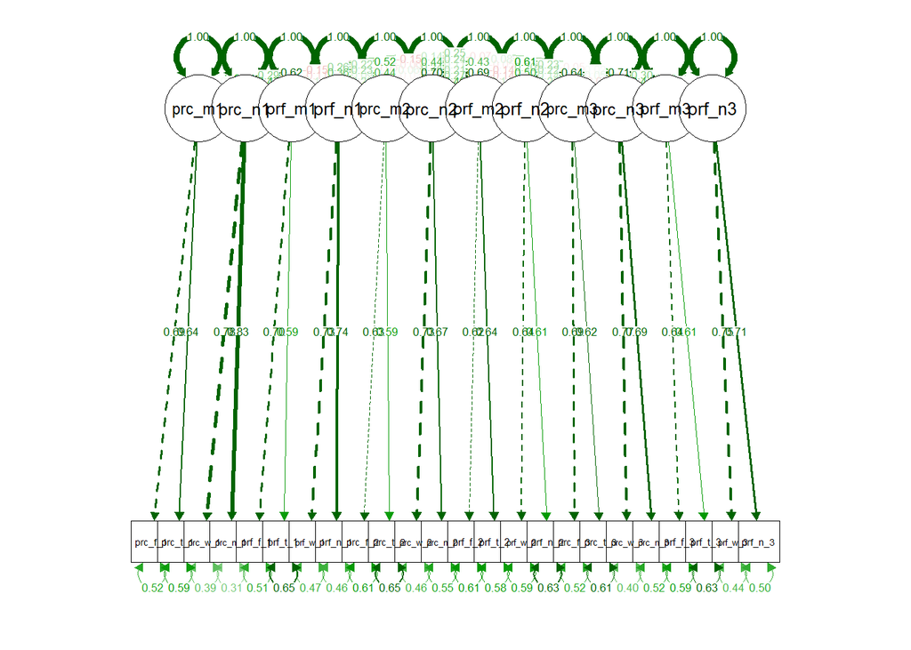

```r
semPlot::semPaths(object = fitlong_c,what = "std",thresholds = FALSE, intercepts = FALSE)
```

```r
#summary(fitlong_o,standardized=TRUE, fit.measures=TRUE)
fitmeasures(fitlong_o)[c("chisq.scaled","df","cfi","cfi.scaled","cfi.robust","rmsea","rmsea.scaled","rmsea.robust")]
```

```
## chisq.scaled           df          cfi   cfi.scaled   cfi.robust
## 747.48098303 186.00000000   0.98273020   0.94727999           NA
##        rmsea rmsea.scaled rmsea.robust
##   0.03597639   0.04567481           NA
```

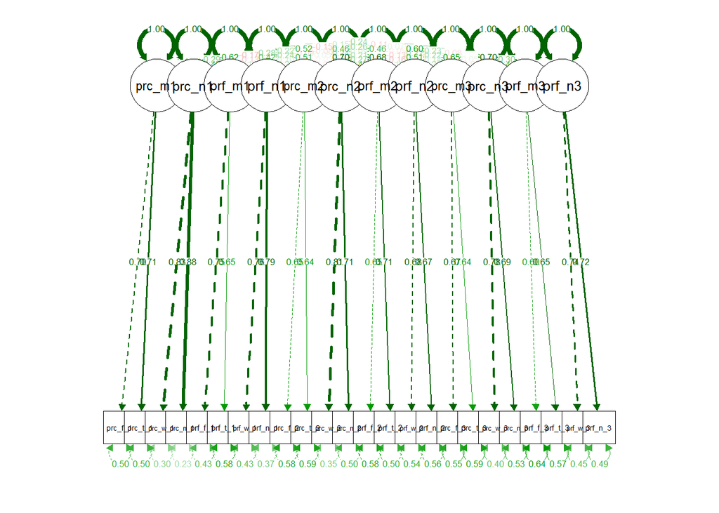

```r
semPlot::semPaths(object = fitlong_o,what = "std",thresholds = FALSE, intercepts = FALSE,style = "mx")
```

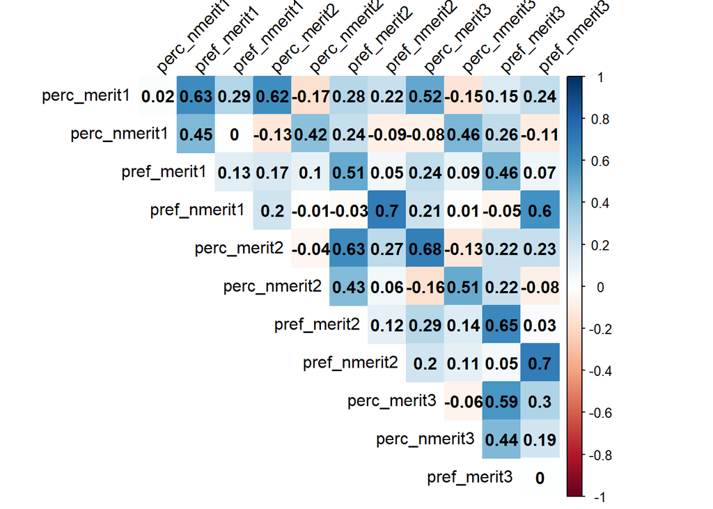

Correlación entre variables latentes w01, w02 y w03

```r
cormat<- as.matrix(inspect(fitlong_o, "cor.lv"))
corrplot(cormat, method = "color" ,type = "upper", tl.col = "black", tl.srt = 45,addCoef.col = "black",diag = FALSE)
```

# 9 Invarianza

1. Invarianza entre modalidades en ola 1,2 y 3 (between groups invariance)
2. Invarianza entre tratamientos en ola 2(between groups invariance)

> **NOTA**: En vista de que no existe una librería que permita estimar invarianza longitudinal asumiendo indicadores ordinales, las primeras estimaciones las realizaré asumiendo indicadores continuos (estimator=ML).

```r
library(semTools)
```

```r
load(file = "input/data/proc/datalong.RData")     # Datos formato long
load(file = "input/data/proc/datawide_123.RData") # Datos formato long
```

```r
dim(dat04)
```

```
## [1] 2236   36
```

```r
m_inv_modalidad <- 'perc_merit=~ perc_effort+perc_talent
                    perc_nmerit=~perc_wpart +perc_netw
                    pref_merit=~ pref_effort+pref_talent
                    pref_nmerit=~pref_wpart +pref_netw'

indicators  <-c("perc_effort","perc_talent","perc_wpart","perc_netw",
                "pref_effort","pref_talent","pref_wpart","pref_netw")

fit.conf=cfa(m_inv_modalidad,data=dat04,group="grupo")
fit.deb =cfa(m_inv_modalidad,data=dat04,group="grupo",group.equal=c("loadings"))
fit.fuer=cfa(m_inv_modalidad,data=dat04,group="grupo",group.equal=c("loadings","intercepts"))
fit.str =cfa(m_inv_modalidad,data=dat04,group="grupo",group.equal=c("loadings","intercepts","residuals"))


fitmeasures(fit.conf)[c("chisq.scaled","df","cfi","cfi.scaled","cfi.robust","rmsea","rmsea.scaled","rmsea.robust")]
```

```
##        <NA>          df         cfi        <NA>        <NA>       rmsea
##          NA 42.00000000  0.95494030          NA          NA  0.07575741
##        <NA>        <NA>
##          NA          NA
```

```r
fitmeasures(fit.deb )[c("chisq.scaled","df","cfi","cfi.scaled","cfi.robust","rmsea","rmsea.scaled","rmsea.robust")]
```

```
##        <NA>          df         cfi        <NA>        <NA>       rmsea
##          NA 50.00000000  0.94850216          NA          NA  0.07422755
##        <NA>        <NA>
##          NA          NA
```

```r
fitmeasures(fit.fuer)[c("chisq.scaled","df","cfi","cfi.scaled","cfi.robust","rmsea","rmsea.scaled","rmsea.robust")]
```

```
##        <NA>          df         cfi        <NA>        <NA>       rmsea
##          NA 58.00000000  0.94733603          NA          NA  0.06969449
##        <NA>        <NA>
##          NA          NA
```

```r
fitmeasures(fit.str )[c("chisq.scaled","df","cfi","cfi.scaled","cfi.robust","rmsea","rmsea.scaled","rmsea.robust")]
```

```
##        <NA>          df         cfi        <NA>        <NA>       rmsea
##          NA 74.00000000  0.91887795          NA          NA  0.07657891
##        <NA>        <NA>
##          NA          NA
```

```r
anova(fit.conf, fit.deb, fit.fuer, fit.str)
```

```
## Chi-Squared Difference Test
##
##          Df   AIC   BIC  Chisq Chisq diff Df diff            Pr(>Chisq)
## fit.conf 42 52068 52578 214.03
## fit.deb  50 52084 52549 246.61     32.579       8            0.00007332 ***
## fit.fuer 58 52081 52500 259.06     12.452       8                0.1321
## fit.str  74 52173 52502 383.70    124.646      16 < 0.00000000000000022 ***
## ---
## Signif. codes:  0 '***' 0.001 '**' 0.01 '*' 0.05 '.' 0.1 ' ' 1
```

```r
configural <- '
# wave 01
perc_merit1 =~NA*perc_effort_w1+lambda1*perc_effort_w1+perc_talent_w1
perc_nmerit1=~NA*perc_wpart_w1 +lambda1*perc_wpart_w1 +perc_netw_w1
pref_merit1 =~NA*pref_effort_w1+lambda1*pref_effort_w1+pref_talent_w1
pref_nmerit1=~NA*pref_wpart_w1 +lambda1*pref_wpart_w1 +pref_netw_w1
# wave 02
perc_merit2 =~NA*perc_effort_w2+lambda1*perc_effort_w2+perc_talent_w2
perc_nmerit2=~NA*perc_wpart_w2 +lambda1*perc_wpart_w2 +perc_netw_w2
pref_merit2 =~NA*pref_effort_w2+lambda1*pref_effort_w2+pref_talent_w2
pref_nmerit2=~NA*pref_wpart_w2 +lambda1*pref_wpart_w2 +pref_netw_w2
# wave 03
perc_merit3 =~NA*perc_effort_w3+lambda1*perc_effort_w3+perc_talent_w3
perc_nmerit3=~NA*perc_wpart_w3 +lambda1*perc_wpart_w3 +perc_netw_w3
pref_merit3 =~NA*pref_effort_w3+lambda1*pref_effort_w3+pref_talent_w3
pref_nmerit3=~NA*pref_wpart_w3 +lambda1*pref_wpart_w3 +pref_netw_w3

# INTERCEPTS: Por cada variable latente, debo fijar el intercepto del primer indicador.
# wave 01--------------------------
perc_effort_w1 ~ i1*1   # Percepcion merito
perc_talent_w1 ~ 1      #
perc_wpart_w1 ~ i1*1    # Percepcion no-merito
perc_netw_w1 ~ 1        #
pref_effort_w1 ~ i1*1   # Preferencia merito
pref_talent_w1 ~ 1      #
pref_wpart_w1 ~ i1*1    # Preferencia no-merito
pref_netw_w1 ~ 1        #

# wave 02--------------------------
perc_effort_w2 ~ i1*1   # Percepcion merito
perc_talent_w2 ~ 1      #
perc_wpart_w2 ~ i1*1    # Percepcion no-merito
perc_netw_w2 ~ 1        #
pref_effort_w2 ~ i1*1   # Preferencia merito
pref_talent_w2 ~ 1      #
pref_wpart_w2 ~ i1*1    # Preferencia no-merito
pref_netw_w2 ~ 1        #

# wave 03--------------------------
perc_effort_w3 ~ i1*1   # Percepcion merito
perc_talent_w3 ~ 1      #
perc_wpart_w3 ~ i1*1    # Percepcion no-merito
perc_netw_w3 ~ 1        #
pref_effort_w3 ~ i1*1   # Preferencia merito
pref_talent_w3 ~ 1      #
pref_wpart_w3 ~ i1*1    # Preferencia no-merito
pref_netw_w3 ~ 1        #

# UNIQUE VARIANCES and COVARIANCES.


# LATENT VARIABLES MEANS: Para cada variable latente fijar la media
# Fix T1 common factor mean to zero
perc_merit1 ~ 0*1
# Freely estimate T2-T3 common factor means
perc_merit2 ~ 1
perc_merit3 ~ 1

perc_nmerit1 ~ 0*1
perc_nmerit2 ~ 1
perc_nmerit3 ~ 1

pref_merit1 ~ 0*1
pref_merit2 ~ 1
pref_merit3 ~ 1

pref_nmerit1 ~ 0*1
pref_nmerit2 ~ 1
pref_nmerit3 ~ 1

# LATENT VARIABLE VARIANCES AND COVARIANCES: correlaciones entre variables latentes

'

fit_conf <- cfa(model = configural,data =wide02)
summary(fit_conf, standardized=TRUE)
```

```
## lavaan 0.6-5 ended normally after 87 iterations
##
##   Estimator                                         ML
##   Optimization method                           NLMINB
##   Number of free parameters                        158
##   Number of equality constraints                    22
##   Row rank of the constraints matrix                22
##
##   Number of observations                          1448
##
## Model Test User Model:
##
##   Test statistic                              1460.610
##   Degrees of freedom                               188
##   P-value (Chi-square)                           0.000
##
## Parameter Estimates:
##
##   Information                                 Expected
##   Information saturated (h1) model          Structured
##   Standard errors                             Standard
##
## Latent Variables:
##                    Estimate  Std.Err  z-value  P(>|z|)   Std.lv  Std.all
##   perc_merit1 =~
##     prc_f_1 (lmb1)    1.313    0.010  126.406    0.000    0.958    0.695
##     prc_t_1           1.013    0.060   16.823    0.000    0.739    0.636
##   perc_nmerit1 =~
##     prc_w_1 (lmb1)    1.313    0.010  126.406    0.000    1.134    0.808
##     prc_n_1           1.221    0.050   24.307    0.000    1.054    0.834
##   pref_merit1 =~
##     prf_f_1 (lmb1)    1.313    0.010  126.406    0.000    1.080    0.774
##     prf_t_1           0.880    0.050   17.469    0.000    0.724    0.596
##   pref_nmerit1 =~
##     prf_w_1 (lmb1)    1.313    0.010  126.406    0.000    1.019    0.772
##     prf_n_1           1.137    0.051   22.487    0.000    0.882    0.766
##   perc_merit2 =~
##     prc_f_2 (lmb1)    1.313    0.010  126.406    0.000    0.780    0.627
##     prc_t_2           1.091    0.068   16.033    0.000    0.648    0.593
##   perc_nmerit2 =~
```

[output cut: 163 more lines]

```
##    .pref_talent_w3    0.726    0.036   20.016    0.000    0.726    0.619
##    .pref_wpart_w3     0.572    0.039   14.826    0.000    0.572    0.421
##    .pref_netw_w3      0.569    0.033   17.421    0.000    0.569    0.484
##     perc_merit1       0.532    0.044   12.096    0.000    1.000    1.000
##     perc_nmerit1      0.746    0.045   16.522    0.000    1.000    1.000
##     pref_merit1       0.677    0.049   13.783    0.000    1.000    1.000
##     pref_nmerit1      0.602    0.040   15.182    0.000    1.000    1.000
##     perc_merit2       0.353    0.033   10.627    0.000    1.000    1.000
##     perc_nmerit2      0.556    0.045   12.392    0.000    1.000    1.000
##     pref_merit2       0.315    0.028   11.229    0.000    1.000    1.000
##     pref_nmerit2      0.340    0.030   11.441    0.000    1.000    1.000
##     perc_merit3       0.403    0.033   12.101    0.000    1.000    1.000
##     perc_nmerit3      0.586    0.042   14.060    0.000    1.000    1.000
##     pref_merit3       0.295    0.026   11.403    0.000    1.000    1.000
##     pref_nmerit3      0.456    0.031   14.481    0.000    1.000    1.000
```

- Invarianza Longitudinal en lavaan https://quantdev.ssri.psu.edu/tutorials/intro-basics-longitudinal-measurement-invariance
- https://users.ugent.be/~yrosseel/lavaan/multiplegroup6Dec2012.pdf
- Invarianza con indicadores categóricos https://www.ncbi.nlm.nih.gov/pmc/articles/PMC5121102/pdf/nihms757737.pdf
- Parametrización tetha: https://groups.google.com/forum/#!topic/lavaan/nfdatPgLLhc
- Colapsing categories: https://www.tandfonline.com/doi/abs/10.1080/10705511.2018.1547640?journalCode=hsem20